# 11 — Probabilistic models 1

Machine Learning (MPA-MLR)

Roman Jakubíček

Department of Biomedical Engineering · FEEC, Brno University of Technology

2025

## Outline

1 · Probability introduction

Distributions, joint, marginal and conditional probability, Bayes’ rule.

2 · Model parameters estimation

A model is a distribution; its parameters have a distribution too.

3 · Maximum likelihood (MLE)

The parameters under which the observed data are the most probable.

4 · Maximum a-posteriori (MAP)

The most probable parameters given the data — likelihood plus a prior.

5 · Bayesian inference

Not one estimate but the whole distribution of the parameters.

Next lecture

Probabilistic models 2 — naive Bayes, Gaussian mixture models with EM, logistic regression.

## 1 · Probability introduction

> Everything today is built from four objects: a distribution, a joint, a marginal and a conditional.

## Definitions

**Probability** — a measure quantifying the likelihood that an event will occur. The probability of an event $A$ is written as
$$P(A) \qquad \big(\text{or } p(A) \text{ or } \Pr(A)\big)$$

**Random variable** $X$ — a variable whose value is uncertain: a dice roll, a covid test result, a class label in a dataset. The probability that $X$ takes the value $x_1$ is $P(X = x_1)$.

**Probability distribution** — the probabilities of occurrence of all possible outcomes of a random variable, i.e. the values $P(X = x_i)$ for all $x_i$.

Notation for the whole course: capital $P(\cdot)$ for the probability of an event or of a discrete value, lower-case $p(\cdot)$ for a density and for the short form $p(x) = P(X = x)$. The third lecture already used $p(x)$, $p(x,y)$ and $p(x \mid y)$ in the entropy formulas — it is the same notation.

## Probability distribution — PMF and PDF

**Probability mass function (PMF)** — discrete variable:
$$P(X = x) = p(x), \qquad \sum_x p(x) = 1$$

**Probability density function (PDF)** — continuous variable:
$$P(X = x) = 0, \qquad P(x_1 \le X \le x_2) = \int_{x_1}^{x_2} p(x)\, dx$$
$$\int_{-\infty}^{\infty} p(x)\, dx = 1$$

For a continuous variable, only an **interval** has a non-zero probability; the density itself is not a probability and may exceed 1.

[figure not shown]

## Probability distribution — non-parametric

**Non-parametric description** — only for a **discrete** distribution; it is given directly by the probability of each value.

$x \in \{1, 3, 7\}$

$P(X = 1) = 0.1$

$P(X = 3) = 0.4$

$P(X = 7) = 0.5$

$x \in \{0.1,\ 1.5,\ 2.3,\ 26.7\}$

$P(X = 0.1) = 0.10$

$P(X = 1.5) = 0.25$

$P(X = 2.3) = 0.38$

$P(X = 26.7) = 0.27$

$x \in \{0, 1\}, \; y \in \{0, 1\}$ — joint:

$P(X = 0, Y = 0) = 0.1$

$P(X = 1, Y = 0) = 0.2$

$P(X = 0, Y = 1) = 0.4$

$P(X = 1, Y = 1) = 0.3$

Each of the three sets sums to 1 — that is the only condition a non-parametric description has to satisfy.

## Non-parametric distribution from observed data

*Feature table* — one row per subject:

| Subject | Feature 1 | Decision |
| --- | --- | --- |
| 01 | Blue | Positive |
| 02 | Blue | Negative |
| 03 | Brown | Positive |
| … | … | … |
| N | Green | Positive |

*Contingency table* — counts:

|  | Blue | Green | Brown | Total |
| --- | --- | --- | --- | --- |
| Positive | 53 | 47 | 45 | **145** |
| Negative | 65 | 33 | 82 | **180** |
| Total | **118** | **80** | **127** | **325** |

*Joint distribution* — divide by 325:

|  | Blue | Green | Brown |
| --- | --- | --- | --- |
| Positive | 0.163 | 0.145 | 0.138 |
| Negative | 0.200 | 0.102 | 0.252 |

Marginals (sum over the other variable): $p(\text{Positive}) = \tfrac{145}{325} = 0.446$, $p(\text{Blue}) = \tfrac{118}{325} = 0.363$

From the feature table we can build any contingency table, but not the other way around. What happens if we have 3 features? Can we build a contingency table from a *continuous* variable?

## Probability distribution — parametric

**Parametric description** — the shape of the distribution is given by a formula with a few parameters. It works for continuous **and** discrete variables.

E.g. the 1D normal distribution is defined by a mean $\mu$ and a standard deviation $\sigma$:
$$f(x \mid \mu, \sigma^2) = \frac{1}{\sqrt{2\pi\sigma^2}}
\exp\!\left( -\frac{(x-\mu)^2}{2\sigma^2} \right)$$

In general we have a **vector of parameters** $\boldsymbol\theta$; for the 1D normal distribution $\boldsymbol\theta = [\mu, \sigma^2]$ — throughout this lecture the normal distribution is written through the **variance** $\sigma^2$, not through $\sigma$.

The whole rest of the lecture is about one question: **given data, which $\boldsymbol\theta$ do we choose?**

## Example — Bernoulli distribution

**Parametric**
$$f(x \mid \theta) = \theta^{x} (1-\theta)^{1-x}$$
$$x \in \{0, 1\}, \qquad \theta = 0.4$$

**Non-parametric**
$$P(X = 0) = 0.6, \qquad P(X = 1) = 0.4$$

From observed data of a **discrete** variable we can obtain both descriptions. For a **continuous** variable only the parametric one exists.

*Feature table*

| Subject | Feature 1 |
| --- | --- |
| 01 | 1 |
| 02 | 0 |
| 03 | 0 |
| … | … |
| N | 1 |

The Bernoulli variable is the one behind DropOut in the sixth lecture, and it will be the likelihood of logistic regression in the next lecture. Here $\theta$ is a **scalar** parameter — the probability of a 1.

## Joint probability

**Joint probability** — the probability of two events happening together. **Joint probability distribution** — the joint probability function of two or more random variables.

*Discrete case (mass function)*
$$P(X = x,\, Y = y) = P(X = x \ \text{and}\ Y = y) = p(x, y)$$

*Continuous case (density function)*
$$P(x_1 \le X \le x_2,\ y_1 \le Y \le y_2), \qquad p(x, y)$$

*Independent variables*
$$p(x, y) = p(x) \cdot p(y)$$

*Dependent variables — chain rule*
$$p(x, y) = p(x \mid y) \cdot p(y)$$

A joint distribution is symmetric: $p(x, y) = p(y, x)$.

## Marginal probability

Marginal probability is the **sum of a joint distribution along one or more dimensions**. The summed-out variables are *marginalized out*; the process is *marginalization*.

Marginalizing along $Y$:
$$P(X = x) = \sum_y P(X = x,\, Y = y)$$

Marginalizing along $X$:
$$P(Y = y) = \sum_x P(X = x,\, Y = y)$$

Abbreviated notation — **law of total probability**:
$$p(x) = \sum_y p(x, y)$$

[figure not shown]

## Conditional probability

**Conditional probability** — the probability that an event $A$ occurs given that another event $B$ has occurred, written $P(A \mid B)$ (or $P(X \mid Y = y)$ for random variables). It is one of the most fundamental concepts in probability theory.

**Kolmogorov definition:** the conditional probability of $A$ given $B$ is the ratio of the probability that both $A$ and $B$ occur to the marginal probability of $B$:
$$p(x \mid y) = \frac{p(x, y)}{p(y)}
\qquad \Longleftrightarrow \qquad
p(x, y) = p(x \mid y) \cdot p(y)$$

In contrast with the joint probability, the conditional probability is **not symmetric** — in general
$$p(x \mid y) \ne p(y \mid x)$$

**By hand**, from the contingency table three slides back: $p(\text{Positive} \mid \text{Blue}) = \tfrac{53}{118} = 0.449$, but $p(\text{Blue} \mid \text{Positive}) = \tfrac{53}{145} = 0.366$ — the same joint count 53 divided by two different marginals.

## Joint, conditional and marginal probability — example

[figure not shown]

Redrawn after Ivezić, Connolly, VanderPlas & Gray, *Statistics, Data Mining, and Machine Learning in Astronomy* (astroML, `fig_conditional_probability`).

## Probability distribution example — shape and colour

[figure not shown]

$X$ — shape: $c$ (circle), $s$ (square); $Y$ — colour: $b$ (blue), $o$ (orange).

Counting the 10 objects (4 squares, 1 of them blue; 6 circles, 2 of them blue):

$$p(s) = \tfrac{4}{10} = 0.4, \qquad p(c) = 0.6, \qquad
p(b) = \tfrac{3}{10} = 0.3, \qquad p(o) = 0.7$$
$$p(b, s) = \tfrac{1}{10} = 0.1 = p(s, b)$$
$$p(b \mid s) = \frac{p(b, s)}{p(s)} = \frac{0.1}{0.4} = 0.25
\qquad
p(s \mid b) = \frac{p(s, b)}{p(b)} = \frac{0.1}{0.3} = 0.33$$
$$p(y) = \sum_x p(x, y) = \sum_{i} p(y \mid x_i)\, p(x_i)$$

$p(b \mid s) = 0.25 \ne 0.33 = p(s \mid b)$, but $p(b, s) = p(s, b) = 0.1$.

## Bayes’ rule

From the definition of conditional probability:
$$p(x, y) = p(x \mid y)\, p(y) = p(y, x) = p(y \mid x)\, p(x)
\quad \Longrightarrow \quad
p(x \mid y)\, p(y) = p(y \mid x)\, p(x)$$

**Bayes’ rule:**
$$\underbrace{p(x \mid y)}_{\textbf{posterior}} =
\frac{\overbrace{p(y \mid x)}^{\textbf{likelihood}}\ \overbrace{p(x)}^{\textbf{prior}}}
{\underbrace{p(y)}_{\textbf{evidence}}}
= \frac{p(y \mid x)\, p(x)}{\sum_{i} p(x_i, y)}
= \boxed{\ \frac{p(y \mid x)\, p(x)}{\sum_{i} p(y \mid x_i)\, p(x_i)}\ }$$

The denominator is just the law of total probability (the sum runs over all values $x_i$ that $X$ can take) — it makes the posterior sum (or integrate) to 1.

## Bayes rule example 1 — smoking and heart attack

$A$ … a person has a heart attack

$B_1$ … non-smoker, $B_2$ … light smoker, $B_3$ … heavy smoker

*Measurement* (100 people with a heart attack):

|  | $B_1$ | $B_2$ | $B_3$ | Total |
| --- | --- | --- | --- | --- |
| $A$ | 50 | 30 | 20 | 100 |

$\Rightarrow$ $p(B_1 \mid A) = 0.5$, $p(B_2 \mid A) = 0.3$, $p(B_3 \mid A) = 0.2$

*Prior:* $p(B_1) = 0.9$, $p(B_2) = 0.07$, $p(B_3) = 0.03$, $p(A) = 0.05$

*Posterior:*
$$p(A \mid B_1) = \frac{p(B_1 \mid A)\, p(A)}{p(B_1)}
= \frac{0.5 \cdot 0.05}{0.9} = 0.0278$$
$$p(A \mid B_2) = \frac{0.3 \cdot 0.05}{0.07} = 0.2143$$
$$p(A \mid B_3) = \frac{0.2 \cdot 0.05}{0.03} = 0.3333$$

Check with the law of total probability:
$$\sum_i p(A \mid B_i)\, p(B_i)
= 0.0278 \cdot 0.9 + 0.2143 \cdot 0.07 + 0.3333 \cdot 0.03$$
$$= 0.05 = p(A)$$

A heavy smoker has a **12× higher** risk than a non-smoker — and the measurement alone (50 : 30 : 20) says nothing of the sort. Only the prior turns it into a risk.

## Bayes rule example 2 — a positive test

$A$ … a disease occurs $\qquad$ $B_+$ … a positive test with **sensitivity and specificity of 98 %**

*Case 1: I have a positive test. What is the probability that I really have the disease?*

**Prevalence 10 %**
$$p(B_+) = p(B_+ \mid A)\, p(A) + p(B_+ \mid \bar A)\, p(\bar A)$$
$$= 0.98 \cdot 0.1 + 0.02 \cdot 0.9 = 0.116$$
$$p(A \mid B_+) = \frac{0.98 \cdot 0.1}{0.116} = 0.845 \approx \mathbf{84\,\%}$$

**Prevalence 1 %**
$$p(B_+) = 0.98 \cdot 0.01 + 0.02 \cdot 0.99 = 0.0296$$
$$p(A \mid B_+) = \frac{0.98 \cdot 0.01}{0.0296} = 0.331 \approx \mathbf{33\,\%}$$

[figure not shown]

$p(A \mid B_+)$ is exactly the **PPV (precision)** from the second lecture; sensitivity is $p(B_+ \mid A)$ and specificity is $p(B_- \mid \bar A)$. [code example — Bayes and prevalence](https://github.com/tomasvicar/MLR/blob/master/lectures_latex_2025/L11/kod/bayes_prevalence.py)

## 2 · Model parameters estimation

> The model is a distribution. Its parameters are uncertain too — so they have a distribution as well.

## Probabilistic models

**Probabilistic models** incorporate random variables and probability distributions into the model of an event or phenomenon. While a deterministic model gives a single possible outcome, a **probabilistic model gives a probability distribution as a solution**.

- We want a model of a probability distribution $p(x)$.
- It can be specified parametrically, with parameters $\boldsymbol\theta$: $p_{\boldsymbol\theta}(x)$.
- Given a measured dataset $D$, the parameters themselves have a distribution:
  $$p(\boldsymbol\theta \mid D) = p(\boldsymbol\theta \mid x_1, x_2, \dots, x_n)$$
- If we know $p(\boldsymbol\theta \mid D)$, we can pick the most probable parameters and use them in the model $p_{\boldsymbol\theta}(x)$.

## Generative vs discriminative models

[figure not shown]

**Discriminative** — $f: X \to Y$, models $p(Y \mid X = x)$

SVM, $k$-NN, logistic regression

**Generative** — models $p(X, Y)$

naive Bayes classifier, conditional GANs, text generation with transformers

**Generative without classes** — models $p(X)$

Gaussian fitted with MLE or MAP, GANs

## Bayes’ terminology for model estimation

**Prior probability** $p(\boldsymbol\theta)$ — the distribution of the parameters before any data is observed (what we know before the experiment).

**Likelihood** $p(D \mid \boldsymbol\theta)$ — the distribution of the observed data given the parameters. It quantifies how likely a model with parameters $\boldsymbol\theta$ is to generate the data $D$.

**Posterior probability** $p(\boldsymbol\theta \mid D)$ — the distribution of the parameters after taking the observed data into account.

**Marginal likelihood (evidence)** $p(D)$ — the distribution of the observed data marginalized over the parameters:
$$p(D) = \sum_{i} p(D \mid \boldsymbol\theta_i)\, p(\boldsymbol\theta_i)
\qquad \text{or} \qquad
p(D) = \int_\Theta p(D \mid \boldsymbol\theta)\, p(\boldsymbol\theta)\, d\boldsymbol\theta$$

Data $D$ and model parameters $\boldsymbol\theta$ — the same Bayes’ rule as before, only $x \to \boldsymbol\theta$ and $y \to D$:
$$\underbrace{p(\boldsymbol\theta \mid D)}_{\text{posterior}} =
\frac{\overbrace{p(D \mid \boldsymbol\theta)}^{\text{likelihood}} \cdot
\overbrace{p(\boldsymbol\theta)}^{\text{prior}}}
{\underbrace{p(D)}_{\text{marginal likelihood}}}$$

The likelihood is **not** a distribution of $\boldsymbol\theta$ — it does not integrate to 1 over $\boldsymbol\theta$. It is a distribution of the data, read as a function of the parameters.

## Example — model parameters estimation

We have $n$ measurements of human height $D = \{x_1, x_2, \dots, x_n\}$, assumed $x_i \sim \mathcal N(\mu, \sigma^2)$:
$$p(x \mid \mu, \sigma^2) = \frac{1}{\sqrt{2\pi\sigma^2}}
\exp\!\left(-\frac{(x-\mu)^2}{2\sigma^2}\right)$$

$x_1 = 172$ cm

$x_2 = 189$ cm

$x_3 = 168$ cm

$\vdots$

$x_n = 163$ cm

[figure not shown]

We are interested in the distribution of the model parameters $p(\boldsymbol\theta \mid D)$, and in the most probable parameters $\arg\max_{\boldsymbol\theta} p(\boldsymbol\theta \mid D)$, where $\boldsymbol\theta = [\mu, \sigma^2]$.

## Parameter estimation methods

[figure not shown]

**Maximum likelihood (MLE)** — under the assumed model the observed data are the most probable.
$$\arg\max_{\boldsymbol\theta} p(D \mid \boldsymbol\theta)$$

**Maximum a-posteriori (MAP)** — the most probable model parameters for the given data.
$$\arg\max_{\boldsymbol\theta} p(\boldsymbol\theta \mid D)
= \arg\max_{\boldsymbol\theta} \frac{p(D \mid \boldsymbol\theta)\, p(\boldsymbol\theta)}{p(D)}$$
$$= \arg\max_{\boldsymbol\theta} p(D \mid \boldsymbol\theta)\, p(\boldsymbol\theta)$$
$p(D)$ is a constant, so it can be dropped inside an $\arg\max$.

**Bayesian inference** — the whole distribution of the parameters for the given data.
$$p(\boldsymbol\theta \mid D)
= \frac{p(D \mid \boldsymbol\theta)\, p(\boldsymbol\theta)}{p(D)}$$
$$= \frac{p(D \mid \boldsymbol\theta)\, p(\boldsymbol\theta)}
{\int_\Theta p(D \mid \boldsymbol\theta)\, p(\boldsymbol\theta)\, d\boldsymbol\theta}$$
The integral is hard to compute.

## 3 · Maximum likelihood

> Choose the parameters that make the data you actually saw as probable as possible.

## Maximum likelihood (ML, MLE)

**The estimation method** that finds the parameters of a probability distribution by maximizing a **likelihood** function for the set of observed data $D = \{x_1, x_2, \dots, x_n\}$. The resulting model **is the most likely model for generating the observed data.**

[figure not shown]

The main advantage is that many problems have an **analytic solution**, so the parameters of a preselected distribution are easy to find. It can also be solved by any optimization technique (brute force, iterative algorithms).

## Definition of ML

**Task:** find the $\boldsymbol\theta$ that maximizes the likelihood
$$\boldsymbol\theta^* = \arg\max_{\boldsymbol\theta} p(D \mid \boldsymbol\theta)$$

If we know that $x_1, x_2, \dots, x_n \sim \mathcal N(\boldsymbol\theta)$ with $\boldsymbol\theta = [\mu, \sigma^2]$, then
$$\mu^* = \arg\max_{\mu} p(D \mid \mu, \sigma^2)$$
$$\sigma^{2*} = \arg\max_{\sigma^2} p(D \mid \mu, \sigma^2)$$

The maximum is where the derivative vanishes — for a smooth likelihood this gives a system of equations, one per parameter.

[figure not shown]

The original slide labels the vertical axis $p(\theta \mid D)$; on a slide about **ML** it must be the likelihood $p(D \mid \boldsymbol\theta)$ — corrected here.

## Likelihood function

PDF of the normal distribution:
$$f(x \mid \mu, \sigma^2) = \frac{1}{\sqrt{2\pi\sigma^2}}
\exp\!\left(-\frac{(x-\mu)^2}{2\sigma^2}\right)$$

For $n$ **independent identically distributed (i.i.d.)** samples $x_i \sim \mathcal N(\mu, \sigma^2)$ the likelihood is a **product**:
$$p(D \mid \mu, \sigma^2) = p(x_1, \dots, x_n \mid \mu, \sigma^2)
= \prod_{i=1}^{n} p(x_i \mid \mu, \sigma^2)
= \prod_{i=1}^{n} \frac{1}{\sqrt{2\pi\sigma^2}}
\exp\!\left(-\frac{(x_i-\mu)^2}{2\sigma^2}\right)$$

[figure not shown]

## Log-likelihood

The logarithm turns the product into a sum and does not move the maximum ($\log$ is monotone):
$$\ell(\mu) = \log p(D \mid \mu, \sigma^2)
= \sum_{i=1}^{n} \log p(x_i \mid \mu, \sigma^2)$$

For a fixed $\sigma$ this is a **parabola** in $\mu$, and its vertex is the sample mean.

Three candidate models from the previous slide are three points on that parabola — the best of them is the one closest to the vertex. Sliding $\mu$ along the axis moves the model over the data and the point along the parabola.

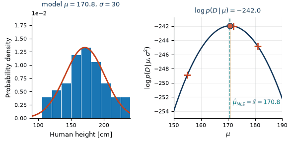

[code example — MLE for the normal distribution, analytically and numerically](https://github.com/tomasvicar/MLR/blob/master/lectures_latex_2025/L11/kod/mle_normal.py)

## Solution for the normal distribution — log-likelihood

Start from the likelihood of $n$ i.i.d. samples and take the logarithm:
$$\log p(x_1, \dots, x_n \mid \mu, \sigma^2)
= \log \prod_{i=1}^{n} \frac{1}{\sqrt{2\pi\sigma^2}}
\exp\!\left(-\frac{(x_i-\mu)^2}{2\sigma^2}\right)$$
$$= \sum_{i=1}^{n} \left[ -\log\!\left(\sqrt{2\pi\sigma^2}\right)
- \frac{1}{2\sigma^2}(x_i - \mu)^2 \right]
= -\frac{n}{2}\log(2\pi\sigma^2) - \frac{1}{2\sigma^2}\sum_{i=1}^{n}(x_i - \mu)^2$$

The first term does not contain $\mu$ at all, and the second one is (up to a negative constant) the **sum of squared errors**. Maximizing the log-likelihood in $\mu$ is therefore the same as minimizing $\sum_i (x_i - \mu)^2$.

That is where the least-squares criterion comes from: it is the maximum likelihood solution under the assumption of additive Gaussian noise.

## Solution for the normal distribution — the estimates

Derivative with respect to $\mu$, set to zero:
$$\frac{d \log p(x_1, \dots, x_n \mid \mu, \sigma^2)}{d\mu}
= \sum_{i=1}^{n} \frac{1}{\sigma^2}(x_i - \mu) = 0
\;\Rightarrow\;
\sum_{i=1}^{n} x_i - n\mu = 0
\;\Rightarrow\;
\hat\mu_{MLE} = \frac{1}{n}\sum_{i=1}^{n} x_i = \bar x$$

The same procedure for $\sigma^2$ gives
$$\hat\sigma^{2}_{MLE} = \frac{1}{n}\sum_{i=1}^{n}(x_i - \bar x)^2$$

On our $n = 50$ heights: $\hat\mu_{MLE} = 170.79$ cm, $\hat\sigma^{2}_{MLE} = 934.3$ cm², i.e. $\hat\sigma_{MLE} = 30.57$ cm.

**By hand** — the first three heights only, $172, 189, 168$:
$$\hat\mu_{MLE} = \tfrac{172 + 189 + 168}{3} = 176.33, \qquad
\hat\sigma^2_{MLE} = \tfrac{(-4.33)^2 + 12.67^2 + (-8.33)^2}{3} = \tfrac{248.67}{3} = 82.9
\ \ (\hat\sigma = 9.1),$$
whereas the unbiased estimate divides by $n - 1 = 2$: $s^2 = 124.3$.

The MLE variance divides by $n$, not by $n-1$, so it is **biased**: $E[\hat\sigma^2_{MLE}] = \frac{n-1}{n}\sigma^2$. With $n = 50$ it underestimates the variance by 2 % — with $n = 3$ by a third. MLE is not guaranteed to be unbiased.

## MLE — pros and cons

**Pros**

- easy to compute — closed-form solution, or a simple maximization problem,
- intuitive interpretation (e.g. the mean for a normal or a Bernoulli distribution).

**Cons**

- **point estimate** — no representation of uncertainty,
- not suitable for a multi-modal likelihood,
- existence and uniqueness are not guaranteed,
- maybe not what we want,
- **overfitting** — e.g. the “black swan paradox”.

[figure not shown]

Black swan paradox: after $n$ observations that are all zeros, MLE gives $\hat\theta = 0$ — “a black swan is impossible”. A Beta$(2,2)$ prior gives $\frac{1}{n+2}$ instead.

## 4 · Maximum a-posteriori probability

> The same maximization, with one extra factor: what we believed before we saw the data.

## Maximum a-posteriori probability (MAP)

**The estimation method** that finds the parameters of a probability distribution by maximizing the **a-posteriori probability** $p(\boldsymbol\theta \mid D)$ for the observed data $D = \{x_1, \dots, x_n\}$.

The resulting model, defined by the estimated parameters, **is the most probable model for the given (observed) data**, taking into account a prior distribution over the individual models.

So we need one more ingredient than MLE: a distribution $p(\boldsymbol\theta)$ over the parameters themselves — here over the mean vector $[\mu_x, \mu_y]$ of the two-dimensional model from the previous block.

[figure not shown]

## MLE versus MAP

**Maximum likelihood**
$$\boldsymbol\theta^*_{MLE} = \arg\max_{\boldsymbol\theta} p(D \mid \boldsymbol\theta)$$

**Maximum a-posteriori probability**
$$\boldsymbol\theta^*_{MAP} = \arg\max_{\boldsymbol\theta} p(\boldsymbol\theta \mid D)$$
$$= \arg\max_{\boldsymbol\theta}
\frac{p(D \mid \boldsymbol\theta) \cdot p(\boldsymbol\theta)}{p(D)}$$
$$= \arg\max_{\boldsymbol\theta}
p(x_1, \dots, x_n \mid \boldsymbol\theta) \cdot p(\boldsymbol\theta)$$

Two terms may be dropped inside the $\arg\max$:

- $p(D)$ — it does not depend on $\boldsymbol\theta$, so it is **irrelevant for finding the maximum**;
- $p(\boldsymbol\theta)$ — only if we assume a **uniform** prior; then MAP degenerates to MLE.

MAP therefore is

- a **regularization** of the ML estimate,
- a way of using a prior distribution of a related event,
- the **mode** of the posterior $p(\boldsymbol\theta \mid D)$, which Bayes’ theorem builds from the likelihood $p(D \mid \boldsymbol\theta)$ and the prior $p(\boldsymbol\theta)$ — still a single point, not the whole posterior.

## Conjugate prior

If the posterior $p(\boldsymbol\theta \mid D)$ and the prior $p(\boldsymbol\theta)$ belong to the same family of distributions, they are called **conjugate distributions** and the prior is a **conjugate prior** for the likelihood $p(D \mid \boldsymbol\theta)$:
$$p(\boldsymbol\theta \mid D) \propto p(D \mid \boldsymbol\theta) \cdot p(\boldsymbol\theta)$$

**Examples**

- a normal likelihood needs a normal prior (for the mean, with known variance),
- a Bernoulli likelihood needs a beta prior,
- more in the [table of conjugate distributions](https://en.wikipedia.org/wiki/Conjugate_prior).

**Why?**

- the analytic solution of the product $p(D \mid \boldsymbol\theta)\, p(\boldsymbol\theta)$ is much easier than with any other prior,
- the update of the prior by the likelihood becomes transparent — it is just arithmetic on the parameters.

## MAP for a normal distribution — likelihood and prior

Likelihood of $n$ independent samples, written with the product pulled out:
$$p(x_1, \dots, x_n \mid \mu, \sigma^2) = \prod_{i=1}^{n} p(x_i \mid \mu, \sigma^2)
= \left(\frac{1}{\sqrt{2\pi\sigma^2}}\right)^{\!n}
\exp\!\left(-\frac{\sum_{i=1}^{n}(x_i-\mu)^2}{2\sigma^2}\right)$$

Prior according to the **conjugate prior** for a normal distribution with known $\sigma$ of the likelihood, $\mu \sim \mathcal N(\mu_0, \sigma_0^2)$:
$$p(\mu \mid \mu_0, \sigma_0^2) = \frac{1}{\sqrt{2\pi\sigma_0^2}}
\exp\!\left(-\frac{(\mu-\mu_0)^2}{2\sigma_0^2}\right),
\qquad \mu_0, \; \sigma_0^2, \; \sigma^2 - \text{constants}$$

Maximize the logarithm of their product:
$$\mathcal P(\mu; \sigma^2, \mu_0, \sigma_0^2)
= \log\big[\, p(x_1, \dots, x_n \mid \mu, \sigma^2) \cdot p(\mu \mid \mu_0, \sigma_0^2) \,\big]$$

## MAP for a normal distribution — the estimate

Setting $\dfrac{d\mathcal P}{d\mu} = 0$ gives a **convex combination** of the sample mean and the prior mean:
$$\mu^*_{MAP} = \arg\max_{\mu} \mathcal P(\mu; \sigma^2, \mu_0, \sigma_0^2)
= \underbrace{\frac{n\sigma_0^2}{n\sigma_0^2 + \sigma^2}}_{\text{weight of the data}}
\cdot \underbrace{\bar x}_{\substack{\text{sample mean}\\ \text{(MLE)}}}
+ \underbrace{\frac{\sigma^2}{n\sigma_0^2 + \sigma^2}}_{\text{weight of the prior}}
\cdot \underbrace{\mu_0}_{\text{prior mean}}$$

The two weights sum to 1, so the MAP estimate always lies **between** $\bar x$ and $\mu_0$:

- $n \to \infty$ or $\sigma_0 \to \infty$ (vague prior) $\Rightarrow$ $\mu^*_{MAP} \to \bar x$, i.e. MLE;
- $n$ small or $\sigma_0$ small (confident prior) $\Rightarrow$ the estimate is pulled towards $\mu_0$.

**By hand** — one measurement $x_1 = 121$, known $\sigma = 6$, prior $\mu_0 = 120$, $\sigma_0 = 12$ (with three measurements the data weight would already be $0.923$ — the blood-pressure example at the end):
$$\text{weights } \tfrac{144}{144 + 36} = 0.8 \ \text{ and } \ 0.2, \qquad
\mu^*_{MAP} = 0.8 \cdot 121 + 0.2 \cdot 120 = 120.8\ \text{mmHg}$$

## MAP — pros and cons

**Pros**

- an analytic solution is usually possible when **conjugate priors** are used (exponential family distributions); otherwise numerical optimization can be used,
- easy to compute (but harder than MLE) and interpretable,
- **reduces overfitting** — the prior acts as a regularizer,
- converges to MLE with enough data.

**Cons**

- **point estimate** — still no representation of uncertainty,
- one must assume a prior on $\boldsymbol\theta$.

Where does the prior come from? Population statistics, previous studies, physical limits — or an honest guess that we should then report.

[code example — MAP versus MLE for a normal distribution with a known $\sigma$](https://github.com/tomasvicar/MLR/blob/master/lectures_latex_2025/L11/kod/map_vs_mle.py)

## 5 · Bayesian inference

> Stop asking for one number. Compute the whole distribution of the parameters.

## Bayesian inference

**The estimation method** that finds the **probability distribution of the model parameters** for the observed data $D = \{x_1, \dots, x_n\}$ — a distribution of models, taking into account a prior distribution over the individual models.

[figure not shown]

Prior × likelihood ∝ posterior, on a grid, for $n = 10$ measurements and a deliberately informative prior centred far from the data, at $(7, 7)$. Even so the data get the weight $\tfrac{n\sigma_0^2}{n\sigma_0^2+\sigma^2} = 0.82$ in $\mu_x$ and the prior only $0.18$, so $\boldsymbol\theta_{MAP}$ moves just $0.5$ away from $\bar x$ — the posterior nearly coincides with the likelihood. MAP is the peak of the right-hand panel; Bayesian inference keeps the whole panel.

## Bayesian inference — the integral

We do not get an estimate $\boldsymbol\theta^*$, but the whole distribution $p(\boldsymbol\theta \mid D)$:
$$p(\boldsymbol\theta \mid D)
= \frac{p(D \mid \boldsymbol\theta)\, p(\boldsymbol\theta)}{p(D)}
= \frac{p(D \mid \boldsymbol\theta)\, p(\boldsymbol\theta)}
{\int_\Theta p(D \mid \boldsymbol\theta)\, p(\boldsymbol\theta)\, d\boldsymbol\theta}$$

The integral in the denominator is hard to compute — and unlike in MAP, where the $\arg\max$ makes it irrelevant, here it **cannot be dropped**.

- **Approximation methods** — Markov Chain Monte Carlo (MCMC: Gibbs sampling, Metropolis–Hastings), Variational Inference. Very complicated; we will not use them in this course.
- **Closed-form solution** for conjugate priors — the case we will actually compute.

## Uncertainty from the posterior

[figure not shown]

A **sketch** of a posterior — any skewed density with its mode at $\theta = 10$ would do. The shaded probability is the real integral of the one drawn; the blood-pressure example later gives the same kind of number from a posterior computed from measurements.

With a known distribution we get the **uncertainty** of the estimate for free.

We know not only that the best model is $\theta = 10$, but we can also compute
$$p(5 < \theta < 15 \mid D) = \int_{5}^{15} p(\theta \mid D)\, d\theta = 0.92$$

That is something no point estimate can give:

- MLE and MAP answer *“which model?”*,
- Bayesian inference answers *“which models, and how much do I believe each of them?”*

## Posterior predictive distribution

For MLE and MAP we get a single model with the optimal $\boldsymbol\theta^*$, and the output distribution is defined by that single model:
$$p(x_{predict} \mid \boldsymbol\theta^*) = p_{\boldsymbol\theta^*}(x_{predict})$$

For Bayesian inference we know the posterior of $\boldsymbol\theta$, so we can compute the **posterior predictive distribution**, which considers all models weighted by their probability:
$$p(x_{predict} \mid D) = \int p(x_{predict} \mid \boldsymbol\theta)\,
p(\boldsymbol\theta \mid D)\, d\boldsymbol\theta$$

It still has a closed-form solution for a conjugate prior, and it is a more honest prediction — it is **wider** than the single-model prediction, because it also contains the uncertainty about $\boldsymbol\theta$.

## Conjugate priors — Bernoulli and Beta

Likelihood — Bernoulli, prior — Beta, posterior — Beta:
$$Beta(\alpha', \beta') \;\propto\; Bernoulli(\theta)\ Beta(\alpha, \beta)$$
$$p(x \mid \theta) = \theta^{x}(1-\theta)^{1-x}$$
$$Beta(\theta \mid \alpha, \beta) =
\frac{\Gamma(\alpha+\beta)}{\Gamma(\alpha)\Gamma(\beta)}\,
\theta^{\alpha-1}(1-\theta)^{\beta-1}$$

The Beta family covers everything we might believe about a probability $\theta \in [0,1]$: flat ($\alpha = \beta = 1$), symmetric, one-sided, even U-shaped.

[figure not shown]

The original slide prints the exponents as $\theta^{1-\alpha}(1-\theta)^{1-\beta}$; the correct Beta density has $\theta^{\alpha-1}(1-\theta)^{\beta-1}$ — as the curves on the very same slide show.

## Bernoulli and Beta — the update

Posterior distribution parameters — pure arithmetic:
$$\alpha' = \alpha + \sum_{i=1}^{n} x_i, \qquad
\beta' = \beta + n - \sum_{i=1}^{n} x_i$$

MAP estimate and posterior predictive:
$$\theta_{MAP} = \frac{\sum_{i=1}^{n} x_i + \alpha - 1}{n + \alpha + \beta - 2},
\qquad
p(\tilde x = 1) = \frac{\alpha'}{\alpha' + \beta'}$$

**Example** — $n = 10$ trials, $\sum_i x_i = 7$ successes, prior $Beta(2,2)$ $\Rightarrow$ posterior $Beta(9, 5)$:
$$\theta_{MLE} = \tfrac{7}{10} = 0.700, \qquad
\theta_{MAP} = \tfrac{8}{12} = 0.667$$
$$p(\tilde x = 1) = \tfrac{9}{14} = 0.643$$

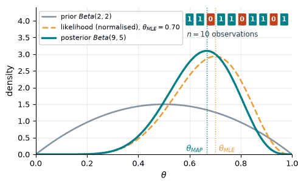

Three different numbers from the same data. The animation adds the observations $1, 1, 0, 1, 1, 0, 1, 1, 0, 1$ one at a time — a $1$ adds one to $\alpha$, a $0$ adds one to $\beta$. [code example — conjugate Beta prior](https://github.com/tomasvicar/MLR/blob/master/lectures_latex_2025/L11/kod/konjugovany_prior_beta.py)

## Conjugate priors — normal and normal

Likelihood — normal with known variance $\sigma^2$, prior — normal, posterior — normal:
$$\mathcal N(x \mid \mu, \sigma^2) = \frac{1}{\sqrt{2\pi\sigma^2}}
\exp\!\left(-\frac{(x-\mu)^2}{2\sigma^2}\right),
\qquad \mu \sim \mathcal N(\mu_0, \sigma_0^2)$$

Posterior distribution parameters:
$$\mu' = \frac{n\sigma_0^2}{n\sigma_0^2+\sigma^2}\cdot \bar x
+ \frac{\sigma^2}{n\sigma_0^2+\sigma^2}\cdot \mu_0 = \mu_{MAP},
\qquad
\sigma'^2 = \left(\frac{1}{\sigma_0^2} + \frac{n}{\sigma^2}\right)^{-1}$$

Posterior predictive:
$$\mathcal N\big(x \mid \mu',\ \sigma'^2 + \sigma^2\big),
\qquad\text{compare with } \mu_{MLE} = \bar x = \frac{1}{n}\sum_{i=1}^{n} x_i$$

The **mean** of the posterior is exactly the MAP estimate from the previous block — but now we also get $\sigma'^2$, the uncertainty of the estimate, and $\sigma'^2 + \sigma^2$, the width of the prediction for a new measurement.

## Bayesian inference — pros and cons

**Pros**

- **not a point estimate** — provides the whole probability distribution of the model parameters, so we know the model uncertainty,
- reduces overfitting,
- can provide an exact **posterior predictive** distribution,
- automatic model selection (through the marginal likelihood).

**Cons**

- one must assume a prior,
- exact computation can be **intractable** — the integral in the denominator.

In deep learning the integral is hopeless, so the practical compromise is MAP: weight decay is a Gaussian prior, and that is all the Bayes most networks ever see.

## Example — MLE and MAP for blood pressure

Model … a normal distribution of the measurement, $x_i \sim \mathcal N(\mu, \sigma^2)$ $\qquad$ $D$ … a set of blood pressure measurements of one subject, $D = \{x_1, \dots, x_n\}$

We assume a normal distribution of the blood pressure measurement and look for the parameters of the posterior distribution $p(\mu \mid D)$. In this example $\sigma$ is **known** — it is the accuracy of the sphygmomanometer — so the estimation reduces to the mean $\mu$ only.

**MLE solution**
$$\mu^*_{MLE} = \arg\max_{\mu} \log p(D \mid \mu;\, \sigma^2) = \bar x$$

**MAP solution** — the conjugate prior is $\mathcal N(\mu_0, \sigma_0^2)$, where $\mu_0$ is the mean blood pressure in the population and $\sigma_0$ its standard deviation in the population:
$$\mu^*_{MAP} = \arg\max_{\mu} \log\big[\, p(D \mid \mu, \sigma^2) \cdot
p(\mu \mid \mu_0, \sigma_0^2) \,\big]
= \frac{n\sigma_0^2}{n\sigma_0^2+\sigma^2}\,\bar x
+ \frac{\sigma^2}{n\sigma_0^2+\sigma^2}\,\mu_0$$

## Example — the numbers

*Observed* ($n = 3$ measurements):

|  | $x_1$ | $x_2$ | $x_3$ |
| --- | --- | --- | --- |
| Observed | 121 | 109 | 115 |

|  | $\mu$ | $\sigma$ |
| --- | --- | --- |
| Measurement (likelihood) | — | 6 |
| Prior (population) | 120 | 12 |

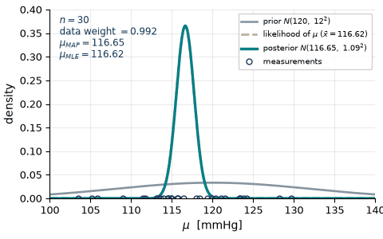

**MLE solution**
$$\mu^*_{MLE} = \bar x = \frac{121 + 109 + 115}{3} = 115\ \text{mmHg}$$

**MAP solution**
$$\mu^*_{MAP} = \frac{3 \cdot 12^2}{3 \cdot 12^2 + 6^2}\cdot 115
+ \frac{6^2}{3 \cdot 12^2 + 6^2}\cdot 120 = 115.38\ \text{mmHg}$$

The weights are $\frac{432}{468} = 0.923$ for the data and $\frac{36}{468} = 0.077$ for the prior — three measurements already outweigh the population.

The animation keeps measuring the same subject (further values drawn from $\mathcal N(115, 6^2)$): the data weight goes $0.8 \to 0.923 \to 0.992$ for $n = 1, 3, 30$ and MAP merges with MLE — the convergence promised on the pros-and-cons slide.

## Example — Bayesian inference solution

*Posterior distribution*
$$\mu' = \mu^*_{MAP} = 115.38\ \text{mmHg}$$
$$\sigma'^2 = \left(\frac{1}{\sigma_0^2} + \frac{n}{\sigma^2}\right)^{-1}
= \left(\frac{1}{12^2} + \frac{3}{6^2}\right)^{-1} = 11.08
\;\Rightarrow\; \sigma' = 3.33$$

*Posterior predictive* — for the **next** measurement of the same subject:
$$\mathcal N\big(x \mid \mu',\, \sigma'^2 + \sigma^2\big)
= \mathcal N\big(x \mid 115.38,\ 11.08 + 6^2 = 47.08\big)$$
i.e. a standard deviation of $6.86$ mmHg.

[figure not shown]

Three measurements shrank the uncertainty about $\mu$ from $\sigma_0 = 12$ to $\sigma' = 3.33$ mmHg — that number is what MLE and MAP cannot give.

## Summary — MLE and MAP

**MLE and MAP** are easy to compute and intuitively interpretable, often with an analytical solution; without one, numerical optimization works too. They provide only a **single estimate** of the parameters, without uncertainty.

**Maximum likelihood**

- maximizes $p(D \mid \boldsymbol\theta)$ — the model that best generates the observed data,
- the estimation is based **only on the observed data**,
- prone to overfitting.

**Maximum a posteriori probability**

- maximizes $p(\boldsymbol\theta \mid D)$ — the most probable model given the observed data,
- requires a prior $p(\boldsymbol\theta)$, which favours some distributions over others,
- the prior acts as a **regularization** and reduces overfitting.

## Summary — Bayesian inference and the three methods

**Bayesian inference** is hard to compute (except for special cases such as conjugate priors). In exchange it provides the **full probability distribution** of the model parameters, and the **posterior predictive distribution** — a mixture of the predictions of all models weighted by their probability. It is similar to MAP, but returns a distribution instead of a point.

|  | what is maximized / computed | needs a prior | output | overfitting |
| --- | --- | --- | --- | --- |
| **MLE** | $p(D \mid \boldsymbol\theta)$ | no | one $\boldsymbol\theta^*$ | yes |
| **MAP** | $p(D \mid \boldsymbol\theta)\, p(\boldsymbol\theta)$ | yes | one $\boldsymbol\theta^*$ | regularized |
| **Bayesian inference** | $p(\boldsymbol\theta \mid D)$ whole | yes | a distribution over $\boldsymbol\theta$ | regularized |

Blood pressure example, all three from the same three measurements: $\mu_{MLE} = 115.00$, $\mu_{MAP} = 115.38$, posterior $\mathcal N(115.38,\ 3.33^2)$, prediction $\mathcal N(115.38,\ 6.86^2)$.

## Where this goes next

**Done today** — Probabilistic models 1

- probability introduction and Bayes’ rule,
- parameter estimation: maximum likelihood, maximum a-posteriori, Bayesian inference.

**Next lecture** — Probabilistic models 2

- naive Bayes classifier,
- Gaussian mixture model and the EM algorithm,
- logistic regression,
- and where loss functions come from: L2 loss is MLE under Gaussian noise, cross-entropy is MLE under a Bernoulli likelihood.

## 6 · Recap

> Three sets of questions: probability, estimation, and the three methods.

## Recap quiz I — probability and Bayes’ rule

- What is the difference between a **PMF** and a **PDF**? Why can a density exceed 1, and what does $P(X = x) = 0$ mean for a continuous variable?
- Write the **chain rule** and the **law of total probability**. Which of them needs independence?
- A contingency table has counts. How do you get the **joint**, the **marginal** and the **conditional** distribution from it?
- Derive **Bayes’ rule** from the symmetry of the joint distribution. Name all four terms.
- A test has sensitivity and specificity 98 %. Why does a positive result mean 84 % at a prevalence of 10 % and only 33 % at 1 %? Which quantity from the second lecture is that?
- On the shapes-and-colours example: why is $p(b \mid s) \ne p(s \mid b)$ while $p(b, s) = p(s, b)$?

## Recap quiz II — likelihood and MLE

- Define **prior**, **likelihood**, **posterior** and **marginal likelihood**. Which of them is not a distribution over $\boldsymbol\theta$?
- Why does the i.i.d. assumption turn the likelihood into a **product**? Why do we take its logarithm?
- Derive $\hat\mu_{MLE} = \bar x$ for a normal distribution. Which term of the log-likelihood does not contain $\mu$ at all?
- Why is $\hat\sigma^2_{MLE}$ **biased**, and how big is the bias for $n = 50$?
- Name three weaknesses of MLE and match each with one of the two sketches of a likelihood function.
- What is the **black swan paradox** and what does it say about point estimates?

## Recap quiz III — MAP and Bayesian inference

- Write $\boldsymbol\theta^*_{MAP}$. Which two terms may be dropped inside the $\arg\max$, and under what condition each?
- What is a **conjugate prior** and why do we care? Give the pair for a Bernoulli likelihood and for a normal likelihood.
- $\mu^*_{MAP}$ is a convex combination of what? What happens to the weights when $n \to \infty$, and when $\sigma_0 \to \infty$?
- Prior $Beta(2,2)$, 7 successes out of 10: compute the posterior, $\theta_{MLE}$, $\theta_{MAP}$ and the posterior predictive. Why are they three different numbers?
- Why can Bayesian inference **not** drop $p(D)$, while MAP can?
- What is the **posterior predictive** distribution, and why is it wider than the prediction of the single best model?
- Blood pressure example: the posterior is $\mathcal N(115.38, 3.33^2)$. Where did $3.33$ come from and why is it smaller than both $\sigma$ and $\sigma_0$?